# Optimized Course Forecast

## Impact on Business

This code was used to produce a minimized class list for scheduling the course offerings in 2020 at the American University of Kurdistan. The function provided by this code was in-part responsible for the following:

- A 20% decrease in the number of classes offered in one year alone, even though the number of students increased by more than 20% in that year.
- Placing 300 returning students into 250 more seats than the year before, and accommodating the new students for that year as well.
- The increase in the Full-Time Registration Capacity from 74% to 94% in one year. Explained in the Degree Audimatons and Forecasting project in my portfolio.
- **Ultimately, we saved costs in classroom space and instructor fees equivalent to more than 30% of tuition revenue for that year.**

This code is currently in use as standard procedure for optimizing the class schedule/timetable before students begin registering each semester.

## Problem Statement

We have a dataset which contains a list of students and the courses for which they have met all pre-requisites, meaning the students qualify to register for these courses for the upcoming year/semester. Some students have up to 15 classes in the list, and some students have only a few, or even 1. There is occassional overlap, and only a few students have the same list of classes.

In the upcoming semester, each student needs to schedule 5 classes. This code generates the shortest list of classes which will accommodate each student with at least 5 classes (if they need, remember some need less), allowing the university to save in costs (classroom space and instructor expenses).

A randomized greedy algorithm is used.

```python
import numpy as np
import pandas as pd
from matplotlib import pyplot as plt
```

First, let's load the dataset into a pandas dataframe. Note: this dataset was produced using a Degree Audit System which I built using Visual Basic Applications.

```python
All_Courses_R2T = pd.read_csv("All_Courses_Ready_To_Take.csv")
All_Courses_R2T = All_Courses_R2T[All_Courses_R2T.Course != 'Completed Undecided Courses']
All_Courses_R2T
```

|  | Student | Course |
| --- | --- | --- |
| 0 | A11700592 | ACCT211 |
| 1 | A11700597 | ACCT211 |
| 2 | A11700600 | ACCT211 |
| 3 | A11800736 | ACCT211 |
| 4 | A11800773 | ACCT211 |
| ... | ... | ... |
| 5463 | A11900711 | SSS401 |
| 5464 | A21500064 | SSS401 |
| 5465 | A21600035 | SSS401 |
| 5466 | A21700280 | SSS401 |
| 5467 | A21700361 | SSS401 |

5444 rows × 2 columns

```python
# Let's look at all the courses for a given student
print(All_Courses_R2T[All_Courses_R2T['Student']=='A11500002'])
```

```
        Student  Course
3002  A11500002  IND420
3063  A11500002  IND422
3136  A11500002  IND425
3165  A11500002  IND426
3171  A11500002  IND427
```

```python
# pivot table to get number of students in each course
Course_List = All_Courses_R2T.pivot_table(index='Course', values='Student', aggfunc='count')
# Sort
Course_List = Course_List.reindex(Course_List['Student'].sort_values(ascending=False).index)
print(Course_List)
```

```
         Student
Course
BUS319       126
BUS327       110
BUS322        90
ECON324       89
MATH310       80
...          ...
ETE312         2
ENV311         2
ENV310         2
IND208         2
ISCI417        1

[253 rows x 1 columns]
```

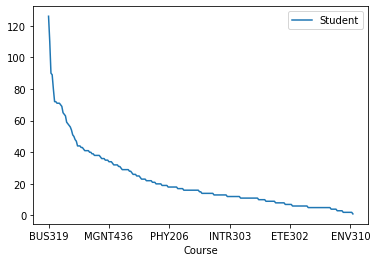

```python
# Let's plot the dataset above, seeing how many students require each course as a plot.
Course_List.plot()
```

```python
# pivot table to get number of courses for each student
Student_List = All_Courses_R2T.pivot_table(index='Student', values='Course', aggfunc='count')
# Sort
Student_List = Student_List.reindex(Student_List['Course'].sort_values(ascending=False).index)
Students_5fewer = Student_List[Student_List['Course'] < 6 ]
```

```python
Students_5fewer
```

| Student | Course |
| --- | --- |
| A11700563 | 5 |
| A21700420 | 5 |
| A21700406 | 5 |
| A21700315 | 5 |
| A21600199 | 5 |
| ... | ... |
| A11700591 | 1 |
| A21600104 | 1 |
| A21700248 | 1 |
| A21901024 | 1 |
| A11900718 | 1 |

80 rows × 1 columns

This is where things get interesting. To produce a minimized class list to accommodate all students with 5, we need to first make a master list and put all the courses for all students who need less than 5, we need to offer all of these classes since these are the only ones they can take. We call this the master list. Then we start with all students who have 6 classes in All_Courses_R2T, we select them one by one and check to see if they have 5 in the master list already. If they do, great we move to the next student, if they do not then we do something different. For examples say that for a given student there are 4 in the master list and 2 of them are not in the list. One needs to be added, randomly select which course to add to the master list and move on to the next student. We do this for all students. By the end, we have a master list.

We run this process again, in the code below it runs 1000 times (n_trials) creating 1000 master lists. Then we select the master list with the smallest length. This produces a minimized list of classes which we can schedule and all students will be accommodated to register for their sufficient number of classes. As n_trials increases to infinity, the likelyhood that this code produces the smallest course list (or one of them since this may not be unique) approaches 1. This can be demonstrated by running the code for n_trials = 1000, then changing it to 10,000 and trying again, then 100,000 and so on.

```python
# Randomizer
min_course_len = 999
min_course_list = []

n_trials = int(1e3)
for j in range(n_trials):
    if j % 10 == 0:
        print(j)
    master_course_list = []
    for student in Students_5fewer.index:
        student_courses = All_Courses_R2T[All_Courses_R2T['Student']==student].Course.values
        master_course_list.extend(student_courses)

    master_course_list = np.unique(master_course_list)
    master_course_list = master_course_list.tolist()

    for k in range(6,21):
        Students_k_avail = Student_List[Student_List['Course'] == k ]
        for student in Students_k_avail.index:
            student_courses = All_Courses_R2T[All_Courses_R2T['Student']==student].Course.values
            intersection = np.intersect1d(master_course_list, student_courses)
            num_match = len(intersection)
            if num_match < 5:
                n_add = 5 - num_match
                avail_not_in_master = np.setdiff1d(student_courses, master_course_list)
                new_courses = np.random.choice(avail_not_in_master, n_add)
                master_course_list.extend(new_courses)

    master_len = len(master_course_list)
    if master_len < min_course_len:
        min_course_len = master_len
        min_course_list = master_course_list

min_course_list = sorted(min_course_list)
print(min_course_len)
print(min_course_list)
```

[output not shown]

[output cut: 47 more lines]

```
870
880
890
900
910
920
930
940
950
960
970
980
990
118
['ACCT211', 'ACCT215', 'ACCT328', 'ACCT429', 'ACCT435', 'ARC302', 'ARC311', 'ARC402', 'ARC410', 'ARC411', 'ARC421', 'ARC500', 'ARC501', 'ARC700', 'ARC702', 'BUS319', 'BUS321', 'BUS323', 'BUS326', 'BUS327', 'BUS434', 'CHEM117', 'CHEM202', 'ECON324', 'ELE-INS2', 'ELE-PEG1', 'ELE-PEG2', 'ENG100', 'ENG1…
```

**Interpretation**

This produced a list of 118 classes. This is a list of classes which we can schedule and offer, then students can register and the average student will have 7 classes to choose from, they can choose 5 if they need and the university has saved costs by offering a minimized list of courses for which expenses are also minimized. For perspective, the semester for which this data was used to make this list there were more than 170 classes offered. For more perspective, a full-time faculty member (instructor) teaches 3 classes per semester and that costs the university an average of around $3,000 per class. For the following semester, we minimized the list of classes which the university scheduled and saved on costs by using the code above.

From the minimized list of 118 classes above, let's check if each student has a minimum of 5 courses to choose from (that is, for students who have more than 5 "Ready to Take"). Let's remove any course in All_Courses_R2T which is not in min_course_list.

```python
All_Courses_R2T
```

|  | Student | Course |
| --- | --- | --- |
| 0 | A11700592 | ACCT211 |
| 1 | A11700597 | ACCT211 |
| 2 | A11700600 | ACCT211 |
| 3 | A11800736 | ACCT211 |
| 4 | A11800773 | ACCT211 |
| ... | ... | ... |
| 5463 | A11900711 | SSS401 |
| 5464 | A21500064 | SSS401 |
| 5465 | A21600035 | SSS401 |
| 5466 | A21700280 | SSS401 |
| 5467 | A21700361 | SSS401 |

5444 rows × 2 columns

```python
All_Courses_R2T.index
```

```
Int64Index([   0,    1,    2,    3,    4,    5,    6,    7,    8,    9,
            ...
            5458, 5459, 5460, 5461, 5462, 5463, 5464, 5465, 5466, 5467],
           dtype='int64', length=5444)
```

Let's check and see how many classes are in this list for each student, making a pivot table...

```python
check_courses_available_4students = All_Courses_R2T
for j in check_courses_available_4students.index:
    if check_courses_available_4students.loc[j,'Course'] not in min_course_list:
        check_courses_available_4students.drop(index=j, axis=0, inplace=True)
print(check_courses_available_4students)
```

```
        Student   Course
0     A11700592  ACCT211
1     A11700597  ACCT211
2     A11700600  ACCT211
3     A11800736  ACCT211
4     A11800773  ACCT211
...         ...      ...
5463  A11900711   SSS401
5464  A21500064   SSS401
5465  A21600035   SSS401
5466  A21700280   SSS401
5467  A21700361   SSS401

[3352 rows x 2 columns]
```

```python
Student_List = check_courses_available_4students.pivot_table(index='Student', values='Course', aggfunc='count')
# Sort
Student_List = Student_List.reindex(Student_List['Course'].sort_values(ascending=False).index)
print(Student_List)
```

```
           Course
Student
A21600079      15
A12001189      15
A11700580      14
A11700686      14
A11700502      14
...           ...
A11700498       1
A11700591       1
A22001144       1
A21700248       1
A21500068       1

[496 rows x 1 columns]
```

```python
# Remove students who are graduating who need less than 5 courses, so we can see if all other students have enough classes.

for j in Student_List.index:
    if j in Students_5fewer.index:
        Student_List.drop(index=j, axis=0, inplace=True)
print(Student_List)
```

```
           Course
Student
A21600079      15
A12001189      15
A11700580      14
A11700686      14
A11700502      14
...           ...
A11700645       5
A21600102       5
A11700674       5
A11700657       5
A21700424       5

[416 rows x 1 columns]
```

Let's check average number of classes available to each student from the minimized course list which we produced above using the randomized greedy algorithm...

```python
Student_List['Course'].mean()
```

```
7.425480769230769
```

```python
Student_List['Course'].median()
```

```
7.0
```

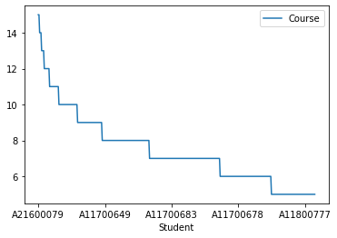

```python
Student_List.plot()
```

```python
# Let's get the number of students who have less than 7 courses to choose from
students_7fewer = []
for j in Student_List.index:
    if Student_List.loc[j, 'Course'] < 7:
        students_7fewer.append(j)
print(students_7fewer)
```

```
['A11700257', 'A11800743', 'A11800753', 'A11800747', 'A11700258', 'A11800737', 'A11700543', 'A11700495', 'A11700500', 'A11700622', 'A11700631', 'A11700616', 'A11700637', 'A11700643', 'A11700648', 'A11700650', 'A11700596', 'A11700593', 'A11700655', 'A11700589', 'A11700587', 'A11700660', 'A11700555', …
```

```python
len(students_7fewer)
```

```
143
```